DOCUMENTO TÉCNICO

**Colegio Universitario de Cartago**  
Big Data  
BD-165 - Modelos estadísticos avanzados de análisis de datos  
Proyecto Final

**Integrantes**

- Marisol Víquez Rivera
- Camila Jimenez
- Gilary Granados Calvo
- Fernando Contreras Artavia
- Johel Barquero

## Introducción

El comercio electrónico genera de forma continua grandes volúmenes de datos sobre clientes, productos y transacciones, cuyo análisis permite comprender mejor el comportamiento de compra y el desempeño del negocio. En este contexto, el presente proyecto tiene como objetivo aplicar técnicas de análisis multivariado a un conjunto de datos de ventas de comercio electrónico, con el fin de identificar patrones de compra, evaluar el efecto de factores como la región y la categoría del producto sobre los ingresos y la satisfacción de los clientes, y analizar el comportamiento de los ingresos mensuales a lo largo del tiempo.

Para ello se emplean tres técnicas estudiadas en el curso: agrupamiento por K-medoids (PAM), para segmentar las transacciones según variables numéricas asociadas al comportamiento de compra; MANOVA, para determinar si la región geográfica y la categoría del producto influyen conjuntamente en el revenue y en el customer rating; y análisis de series temporales.

A partir de estos análisis, el proyecto busca responder tres preguntas centrales: Identificar patrones de comportamiento de compra entre las transacciones registradas.¿La región geográfica y la categoría del producto influyen en el desempeño de las ventas (revenue) y en la satisfacción de los clientes (customer rating) de una tienda? ¿Cuál es la tendencia y el patrón estacional de los ingresos (revenue) mensuales de la tienda en línea entre 2022 y 2025, y qué modelo de suavización exponencial (SES, Holt o Holt-Winters) predice mejor las ventas futuras?

## Descripción de los datos

Este conjunto de datos contiene 5.000 transacciones minoristas sintéticas pero altamente realistas, diseñadas para reflejar la dinámica moderna del mercado online. Conecta la demografía de los clientes, la categorización de productos, las métricas financieras y la logística operativa en un único activo analítico coherente.

**Variables:**

Finanzas: Precios unitarios, cantidades, porcentajes de descuento aplicados e ingresos netos.

Logística: Diferencias temporales entre las fechas de pedido y las fechas de envío.

## Exploración y preparación

### Carga de datos

[output not shown]

[output not shown]

[output not shown]

```
##   order_id order_date customer_id product_category region quantity unit_price
## 1    10001   1/1/2022        1102           Beauty  South        7     373.65
## 2    10002   1/2/2022        1435         Clothing  South        7      47.74
## 3    10003   1/3/2022        1860           Beauty   East        3     311.28
## 4    10004   1/4/2022        1270      Electronics   West        5     524.47
## 5    10005   1/5/2022        1106         Clothing   West        5     139.87
## 6    10006   1/6/2022        1071      Electronics   West        2     264.44
##   discount payment_method delivery_days customer_rating revenue
## 1     0.28         Wallet            10             4.7 1883.20
## 2     0.09           Card             6             3.9  304.10
## 3     0.31            COD             6             2.5  644.35
## 4     0.02         Wallet             6             1.6 2569.90
## 5     0.33         Wallet             4             4.9  468.56
## 6     0.20           Card             3             3.3  423.10
```

### Tipos de variables

```
## 'data.frame':    5000 obs. of  12 variables:
##  $ order_id        : int  10001 10002 10003 10004 10005 10006 10007 10008 10009 10010 ...
##  $ order_date      : chr  "1/1/2022" "1/2/2022" "1/3/2022" "1/4/2022" ...
##  $ customer_id     : int  1102 1435 1860 1270 1106 1071 1700 1020 1614 1121 ...
##  $ product_category: chr  "Beauty" "Clothing" "Beauty" "Electronics" ...
##  $ region          : chr  "South" "South" "East" "West" ...
##  $ quantity        : int  7 7 3 5 5 2 6 6 6 4 ...
##  $ unit_price      : num  373.6 47.7 311.3 524.5 139.9 ...
##  $ discount        : num  0.28 0.09 0.31 0.02 0.33 0.2 0.23 0.13 0.27 0.06 ...
##  $ payment_method  : chr  "Wallet" "Card" "COD" "Wallet" ...
##  $ delivery_days   : int  10 6 6 6 4 3 1 2 2 10 ...
##  $ customer_rating : num  4.7 3.9 2.5 1.6 4.9 3.3 1.8 3.7 1.4 4.5 ...
##  $ revenue         : num  1883 304 644 2570 469 ...
```

### Resumen del dataset

```
##     order_id         order_date    customer_id    product_category
##  Min.   :10001   Length   :5000   Min.   :1000   Length   :5000
##  1st Qu.:11251   N.unique :5000   1st Qu.:1253   N.unique :   4
##  Median :12500   N.blank  :   0   Median :1510   N.blank  :   0
##  Mean   :12500   Min.nchar:   8   Mean   :1506   Min.nchar:   4
##  3rd Qu.:13750   Max.nchar:  10   3rd Qu.:1761   Max.nchar:  11
##  Max.   :15000                    Max.   :1999
##        region        quantity       unit_price        discount
##  Length   :5000   Min.   :1.000   Min.   : 15.15   Min.   :0.00
##  N.unique :   4   1st Qu.:2.000   1st Qu.:161.90   1st Qu.:0.09
##  N.blank  :   0   Median :4.000   Median :309.89   Median :0.18
##  Min.nchar:   4   Mean   :4.045   Mean   :308.42   Mean   :0.18
##  Max.nchar:   5   3rd Qu.:6.000   3rd Qu.:455.56   3rd Qu.:0.27
##                   Max.   :7.000   Max.   :599.96   Max.   :0.35
##    payment_method delivery_days    customer_rating    revenue
##  Length   :5000   Min.   : 1.000   Min.   :1.000   Min.   :  11.21
##  N.unique :   3   1st Qu.: 3.000   1st Qu.:2.000   1st Qu.: 354.53
##  N.blank  :   0   Median : 6.000   Median :3.000   Median : 796.65
##  Min.nchar:   3   Mean   : 6.119   Mean   :2.974   Mean   :1021.96
##  Max.nchar:   6   3rd Qu.: 9.000   3rd Qu.:4.000   3rd Qu.:1515.69
##                   Max.   :11.000   Max.   :5.000   Max.   :4119.33
```

### Dimensiones del df

```
## [1] 5000   12
```

### Nulos

```
##         order_id       order_date      customer_id product_category
##                0                0                0                0
##           region         quantity       unit_price         discount
##                0                0                0                0
##   payment_method    delivery_days  customer_rating          revenue
##                0                0                0                0
```

### Duplicados

```
## [1] 0
```

### Tablas de Frecuencias

```
##
##      Beauty    Clothing Electronics        Home
##         723        1531        1777         969
```

```
##
##  East North South  West
##  1227  1276  1208  1289
```

```
##
##   Card    COD Wallet
##   2270   1774    956
```

```
##
##      Beauty    Clothing Electronics        Home
##      0.1446      0.3062      0.3554      0.1938
```

### Visualizaciones

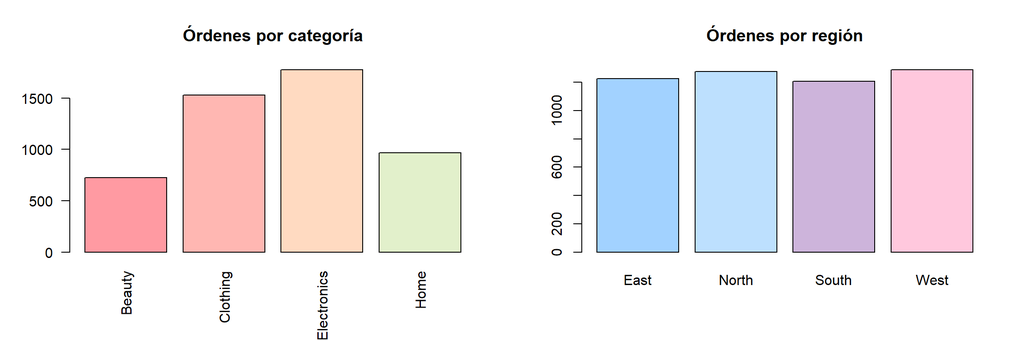

### Análisis bivariado

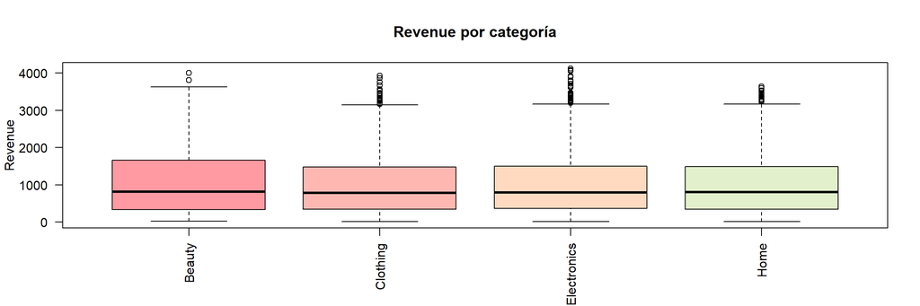

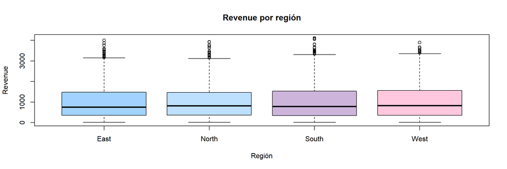

### Cambiar el formato de la fecha

```
## [1] "2022-01-01" "2035-09-09"
```

```
##
## 2022-01 2022-02
##      31      28
```

### Preparación para MANOVA

```
## 'data.frame':    5000 obs. of  13 variables:
##  $ order_id        : int  10001 10002 10003 10004 10005 10006 10007 10008 10009 10010 ...
##  $ order_date      : chr  "2022-01-01" "2022-01-02" "2022-01-03" "2022-01-04" ...
##  $ customer_id     : int  1102 1435 1860 1270 1106 1071 1700 1020 1614 1121 ...
##  $ product_category: Factor w/ 4 levels "Beauty","Clothing",..: 1 2 1 3 2 3 2 1 2 2 ...
##  $ region          : Factor w/ 4 levels "East","North",..: 3 3 1 4 4 4 3 2 3 4 ...
##  $ quantity        : int  7 7 3 5 5 2 6 6 6 4 ...
##  $ unit_price      : num  373.6 47.7 311.3 524.5 139.9 ...
##  $ discount        : num  0.28 0.09 0.31 0.02 0.33 0.2 0.23 0.13 0.27 0.06 ...
##  $ payment_method  : chr  "Wallet" "Card" "COD" "Wallet" ...
##  $ delivery_days   : int  10 6 6 6 4 3 1 2 2 10 ...
##  $ customer_rating : num  4.7 3.9 2.5 1.6 4.9 3.3 1.8 3.7 1.4 4.5 ...
##  $ revenue         : num  1883 304 644 2570 469 ...
##  $ mes             : chr  "2022-01" "2022-01" "2022-01" "2022-01" ...
```

```
##   order_id order_date customer_id product_category region quantity unit_price
## 1    10001 2022-01-01        1102           Beauty  South        7     373.65
## 2    10002 2022-01-02        1435         Clothing  South        7      47.74
## 3    10003 2022-01-03        1860           Beauty   East        3     311.28
## 4    10004 2022-01-04        1270      Electronics   West        5     524.47
## 5    10005 2022-01-05        1106         Clothing   West        5     139.87
## 6    10006 2022-01-06        1071      Electronics   West        2     264.44
##   discount payment_method delivery_days customer_rating revenue     mes
## 1     0.28         Wallet            10             4.7 1883.20 2022-01
## 2     0.09           Card             6             3.9  304.10 2022-01
## 3     0.31            COD             6             2.5  644.35 2022-01
## 4     0.02         Wallet             6             1.6 2569.90 2022-01
## 5     0.33         Wallet             4             4.9  468.56 2022-01
## 6     0.20           Card             3             3.3  423.10 2022-01
```

```
##
##         Beauty Clothing Electronics Home
##   East     165      395         418  249
##   North    194      378         462  242
##   South    172      365         455  216
##   West     192      393         442  262
```

```
## # A tibble: 16 × 4
##    region product_category media_revenue media_rating
##    <fct>  <fct>                    <dbl>        <dbl>
##  1 East   Beauty                   1060.         2.95
##  2 East   Clothing                 1019.         3.07
##  3 East   Electronics               985.         2.91
##  4 East   Home                      991.         2.95
##  5 North  Beauty                    960.         3.17
##  6 North  Clothing                  965.         2.95
##  7 North  Electronics              1023.         2.94
##  8 North  Home                     1067.         3.03
##  9 South  Beauty                   1111.         2.97
## 10 South  Clothing                  954.         2.97
## 11 South  Electronics              1070.         2.99
## 12 South  Home                     1019.         2.93
## 13 West   Beauty                   1113.         2.93
## 14 West   Clothing                 1059.         3.03
## 15 West   Electronics              1038.         2.97
## 16 West   Home                      981.         2.86
```

## Modelos aplicados

### K-medoids

#### ¿Qué patrones de compra pueden identificarse mediante K-Medoids?

Se aplicó la técnica de agrupamiento K-medoids (PAM, *Partitioning Around Medoids*) sobre las variables numéricas, con el objetivo de identificar patrones de comportamiento de compra entre las transacciones registradas.

Previo al modelado, las variables numéricas fueron estandarizadas. El número de clústeres (k=3) se determinó mediante el método del codo (que se mostrará más adelante), evaluando la suma de cuadrados dentro de los grupos para valores de k entre 1 y 6.

```r
# PAM k-medoids
set.seed(123)
pam_fit <- pam(datos_medoids, k = 3)
```

```r
pam_fit$clustering
pam_fit$medoids
```

[output not shown]

### MANOVA

#### ¿La región geográfica y la categoría del producto influyen en el desempeño de las ventas (revenue) y en la satisfacción de los clientes (customer rating) de una tienda?

```
## Prueba de Henze-Zirkler
## HZ = 66.48308
## p = 0
## No existe normalidad multivariada
```

```
##
##  Shapiro-Wilk normality test
##
## data:  res[, "revenue"]
## W = 0.90659, p-value < 2.2e-16
```

```
##
##  Shapiro-Wilk normality test
##
## data:  res[, "customer_rating"]
## W = 0.95763, p-value < 2.2e-16
```

```
##
##  Box's M-test for Homogeneity of Covariance Matrices
##
## data:  datos[, c("revenue", "customer_rating")]
## Chi-Sq (approx.) = 43.493, df = 45, p-value = 0.5359
```

```
## Levene's Test for Homogeneity of Variance (center = median)
##         Df F value Pr(>F)
## group   15  1.1607 0.2953
##       4984
```

```
## Levene's Test for Homogeneity of Variance (center = median)
##         Df F value Pr(>F)
## group   15   1.367 0.1539
##       4984
```

```
##                           Df    Pillai approx F num Df den Df Pr(>F)
## region                     3 0.0005237  0.43515      6   9968 0.8558
## product_category           3 0.0012060  1.00237      6   9968 0.4217
## region:product_category    9 0.0043160  1.19762     18   9968 0.2525
## Residuals               4984
```

```
##  Response revenue :
##                           Df     Sum Sq Mean Sq F value Pr(>F)
## region                     3    1400068  466689  0.6847 0.5613
## product_category           3    1869931  623310  0.9145 0.4330
## region:product_category    9    7033551  781506  1.1466 0.3255
## Residuals               4984 3396961375  681573
##
##  Response customer_rating :
##                           Df Sum Sq Mean Sq F value Pr(>F)
## region                     3    0.7 0.23917  0.1784 0.9111
## product_category           3    4.4 1.45937  1.0888 0.3524
## region:product_category    9   15.1 1.68237  1.2552 0.2562
## Residuals               4984 6680.0 1.34029
```

### Series temporales

#### ¿Cuál es la tendencia y el patrón estacional de los ingresos (revenue) mensuales de la tienda en línea entre 2022 y 2025, y qué modelo de suavización exponencial (SES, Holt o Holt-Winters) predice mejor las ventas futuras?

```
##            Jan       Feb       Mar       Apr       May       Jun       Jul
## 2022 1149.1900 1068.1746  977.7187 1026.0653 1342.8787  994.9110  925.3626
## 2023 1219.2200 1106.4414  849.7658  870.0703 1047.8213 1169.4217  896.4077
## 2024  845.0994 1106.1186 1082.8735  866.1737 1150.7932  838.7300  793.1577
## 2025  772.0968  993.7661 1023.5210  716.7593  938.6548 1024.2603 1101.3297
##            Aug       Sep       Oct       Nov       Dec
## 2022  941.4984  959.7023  944.0500 1077.6497  821.4165
## 2023  970.0816 1099.2107  945.1606 1005.3840  865.5052
## 2024 1308.1845 1085.3370  728.4874 1052.3033 1054.4806
## 2025 1154.8532 1033.6740  667.0597  835.0350 1235.5500
```

```
##                       ME     RMSE      MAE       MPE     MAPE      MASE
## Training set -0.03272895 149.0974 120.2545 -2.389959 12.67685 0.8845945
##                     ACF1
## Training set -0.08182396
```

```
##                    ME     RMSE      MAE       MPE     MAPE      MASE
## Training set 8.798958 154.1951 121.8081 -1.498053 12.72296 0.8960227
##                     ACF1
## Training set -0.05603322
```

```
##                     ME     RMSE      MAE       MPE     MAPE      MASE
## Training set -8.506621 129.0752 104.6658 -2.419562 10.71834 0.7699233
##                     ACF1
## Training set -0.03725048
```

## Resultados

### K-medoids

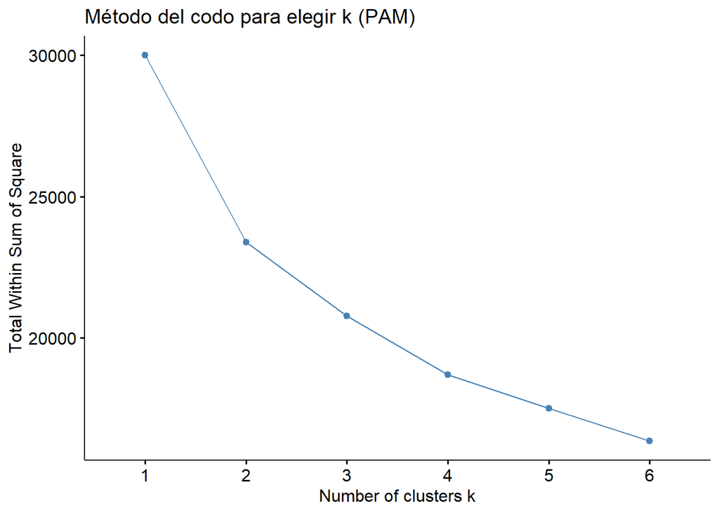

La reducción en la dispersión se suaviza a partir de k=3, por lo que se seleccionó este valor para el modelo.

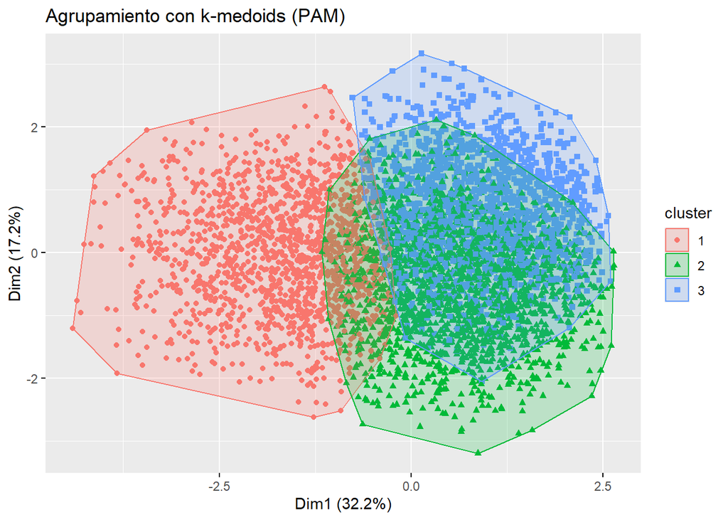

Se identifican 3 clústeres con cierta separación; los clústeres 2 y 3 muestran solapamiento parcial.

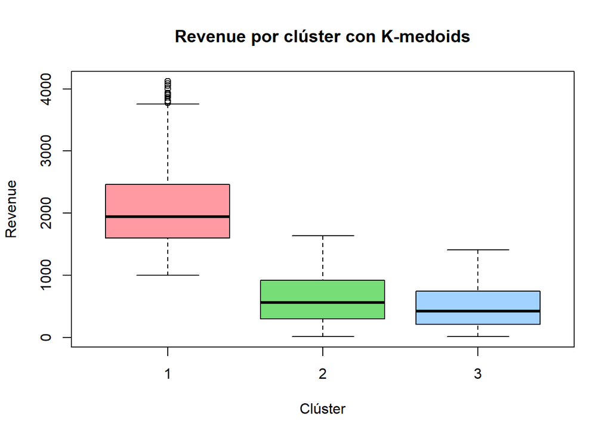

El clúster 1 concentra las compras de mayor valor, mientras los clústeres 2 y 3 presentan montos similares y más bajos.

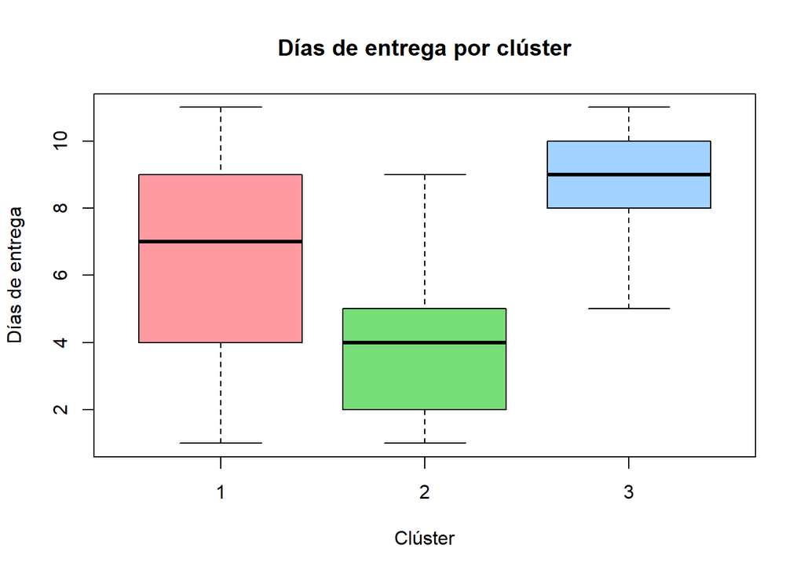

El clúster 2 tiene las entregas más rápidas y el clúster 3 las más lentas, diferenciándolos pese a tener revenue similar.

```
##
##     Beauty Clothing Electronics Home
##   1    234      460         534  287
##   2    264      615         707  384
##   3    225      456         536  298
```

### MANOVA

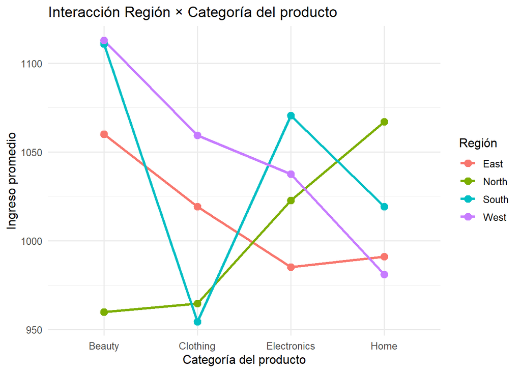

##### Interpretación del gráfico de interacción MANOVA:

El gráfico muestra que el ingreso promedio varía entre las regiones según la categoría del producto. Por ejemplo, South y West presentan los mayores ingresos en la categoría Beauty, mientras que North destaca en Home. Aunque las líneas se cruzan y sugieren visualmente una posible interacción entre la región y la categoría del producto, el MANOVA indicó que dicha interacción no es estadísticamente significativa (p = 0.2525). Por ello, las diferencias observadas pueden atribuirse a la variabilidad de los datos y no a un efecto real entre ambos factores.

### Series temporales

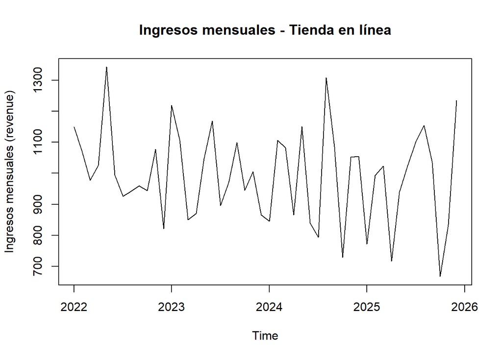

Gráfico Ingresos mensuales - Tienda en línea

La serie de ingresos mensuales presenta una alta variabilidad durante el período 2022–2025, con meses de ingresos elevados y otros con disminuciones considerables. No se observa una tendencia general claramente creciente o decreciente, ya que los ingresos cambian continuamente a lo largo del período. Además, se perciben variaciones que podrían repetirse entre los años, lo que sugiere la posible existencia de un componente estacional que será analizado mediante la descomposición de la serie.

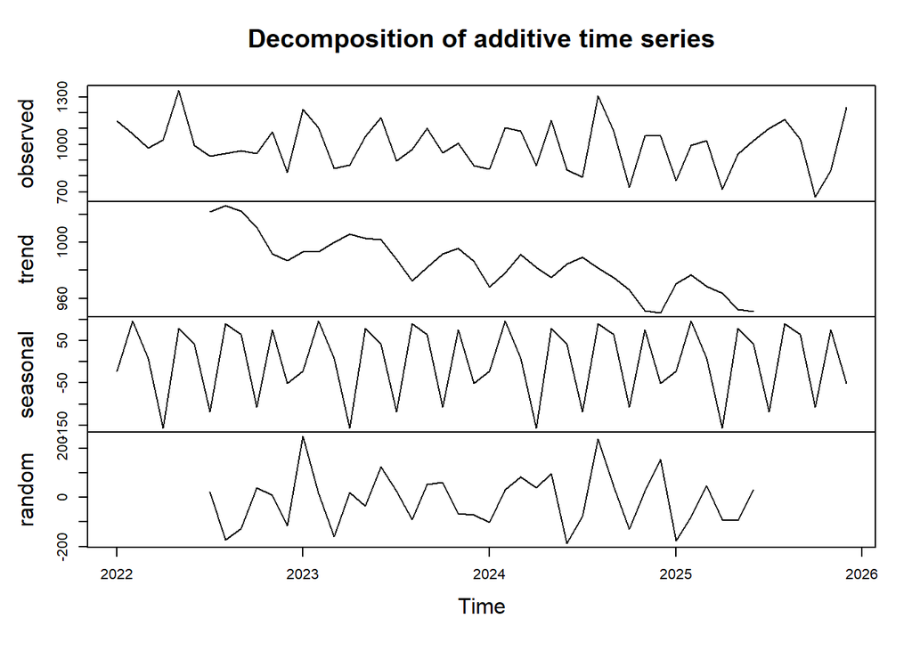

Gráfico de la descomposición temporal

La descomposición de la serie muestra que los ingresos presentan una tendencia variable, con una disminución hacia los últimos períodos. El componente estacional presenta un patrón repetitivo entre los años, evidenciando que determinados meses tienden a presentar ingresos relativamente mayores o menores de forma periódica. Finalmente, el componente aleatorio presenta fluctuaciones importantes, indicando que existen variaciones en los ingresos que no son explicadas completamente por la tendencia ni por la estacionalidad.

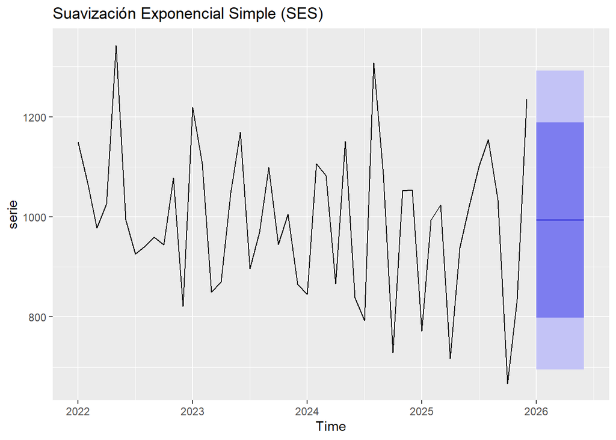

Gráfico Suavización Exponencial Simple (SES)

La suavización exponencial simple genera una línea casi constante, ya que solo considera el nivel promedio de los ingresos. El modelo no toma en cuenta la tendencia ni la estacionalidad, por lo que no sigue los picos y disminuciones de la serie. El pronóstico para 2026 se mantiene prácticamente estable. Esto indica que el modelo no representa adecuadamente el comportamiento de los ingresos.

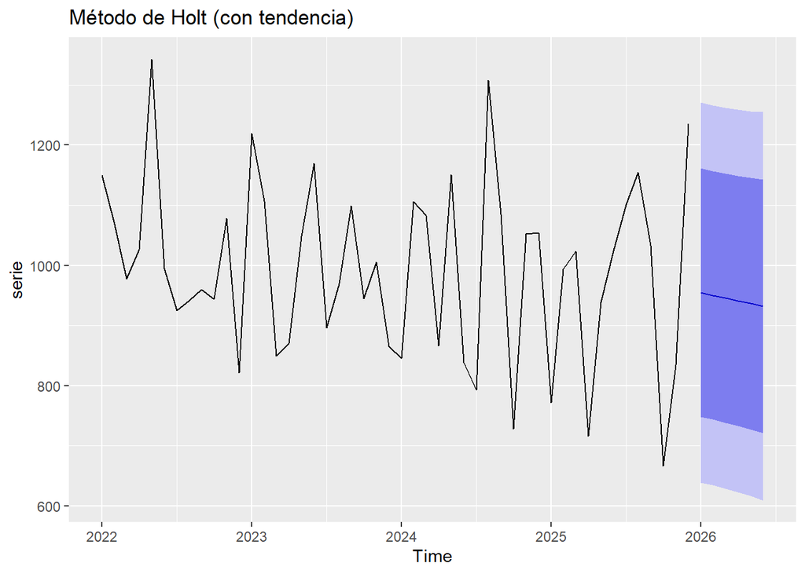

Gráfico Método de Holt (con tendencia)

El método de Holt considera la tendencia de los ingresos, por lo que la línea presenta una disminución a lo largo del tiempo. Sin embargo, no considera la estacionalidad, por lo que no logra representar los cambios mensuales de la serie. El pronóstico continúa con una tendencia decreciente, indicando que los ingresos podrían seguir disminuyendo.

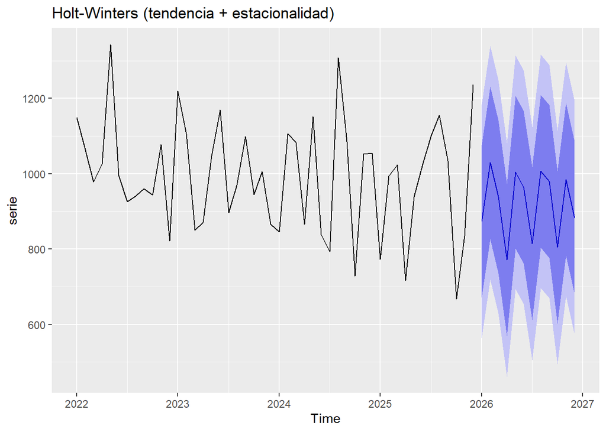

Gráfico Holt-Winters (tendencia + estacionalidad)

El método de Holt-Winters considera tanto la tendencia como la estacionalidad. Por eso, logra representar mejor los picos y disminuciones de los ingresos. Además, mantiene la tendencia decreciente observada en la serie. El pronóstico muestra que los ingresos podrían continuar disminuyendo, pero conservando un comportamiento estacional.

## Discusión

### K-medoids

Los resultados de K-medoids muestran que las transacciones se agrupan en tres patrones diferenciados principalmente por el valor de la compra y el tiempo de entrega. El clúster 1 concentra compras de mayor valor, y los clústeres 2 y 3, se distinguen por tener entregas rápidas y lentas explicando el solapamiento parcial observado entre ellos en la visualización.

**Limitación:** la elección de k=3 mediante el método del codo es parcialmente subjetiva, ya que la curva no presenta un quiebre muy marcado.

### MANOVA

El MANOVA evaluó si la región, la categoría del producto y su interacción influyen conjuntamente en revenue e customer_rating. Los resultados obtenidos fueron:

Efecto Valor p Interpretación Región 0.8558 No significativo Categoría del producto 0.4217 No significativo Región × Categoría 0.2525 No significativo

Como todos los valores p son mayores que 0.05, no se encontraron diferencias multivariadas significativas. Esto indica que las regiones, las categorías de productos y su interacción no influyen de forma conjunta en los ingresos ni en la calificación de los clientes.

### ANOVA

Como seguimiento al MANOVA, se realizaron ANOVA individuales para cada variable dependiente.

##### Revenue

Los valores p fueron:

Región = 0.5613 Categoría del producto = 0.4330 Interacción = 0.3255

Todos son mayores que 0.05, por lo que no existen diferencias significativas en los ingresos promedio entre los grupos evaluados.

##### Customer Rating

Los valores p fueron:

Región = 0.9111 Categoría del producto = 0.3524 Interacción = 0.2562

De igual forma, no se encontraron diferencias significativas en la calificación de los clientes. Estos resultados confirman las conclusiones obtenidas en el MANOVA.

### Series temporales

Modelo con los errores más bajos

El modelo Holt-Winters obtuvo los errores más bajos, con un MAE de 104.67, un RMSE de 129.08 y un MAPE de 10.72%. En comparación, SES obtuvo un MAE de 120.25, un RMSE de 149.10 y un MAPE de 12.68%, mientras que Holt presentó un MAE de 121.81, un RMSE de 154.20 y un MAPE de 12.72%.

Estos resultados indican que incorporar la estacionalidad mejora el pronóstico, ya que Holt-Winters presenta menores errores que SES y Holt. Por lo tanto, los resultados confirman que considerar tanto la tendencia como la estacionalidad permite representar mejor el comportamiento de los ingresos.

Pregunta

¿Cuál de los tres reproduce mejor el patrón de la serie en su pronóstico? ¿Por qué?

El modelo de Holt-Winters reproduce mejor el patrón de la serie, porque considera tanto la tendencia como la estacionalidad de los ingresos. A diferencia de SES, que mantiene un pronóstico casi constante, y de Holt, que solo considera la tendencia, Holt-Winters logra representar mejor los picos y disminuciones de la serie. Por esto, es el modelo que mejor se adapta al comportamiento observado y permite un pronóstico más acorde con el patrón de los ingresos.

## Conclusiones

### K-medoids

El agrupamiento con K-medoids (PAM) permitió identificar tres patrones diferenciados de comportamiento de compra entre las transacciones, principalmente en función del valor de la compra (revenue) y del tiempo de entrega (delivery_days). El clúster 1 se distingue por concentrar las compras de mayor valor, mientras que los clústeres 2 y 3, con montos de compra similares y más bajos, se diferencian entre sí por la rapidez de la entrega: el clúster 2 agrupa las entregas más rápidas y el clúster 3 las más lentas. Este solapamiento parcial entre los clústeres 2 y 3 en la visualización confirma que la separación entre patrones de compra es más clara en la dimensión del valor de la compra que en la logística de entrega.

En términos generales, la técnica permitió segmentar a los clientes en grupos con perfiles de compra distintos, lo cual resulta útil para orientar estrategias comerciales diferenciadas (por ejemplo, priorizar tiempos de entrega para el segmento de mayor valor).

### MANOVA

De acuerdo con los resultados del MANOVA, no existen diferencias estadísticamente significativas en el ingreso (revenue) ni en la calificación del cliente (customer_rating) entre las distintas regiones, categorías de productos o la interacción entre ambos factores, ya que todos los valores p obtenidos fueron mayores que 0.05 (Región: p = 0.8558; Categoría del producto: p = 0.4217; Interacción: p = 0.2525).

Aunque el gráfico de interacción muestra variaciones en los ingresos promedio entre las regiones para algunas categorías de productos, estas diferencias no son lo suficientemente grandes para concluir que exista un efecto real desde el punto de vista estadístico. En consecuencia, se concluye que las variaciones observadas pueden atribuirse a la variabilidad natural de los datos y no a un efecto significativo de la región, la categoría del producto o de la combinación de ambas.

### Series temporales

La serie de ingresos mensuales del período 2022–2025 presenta una alta variabilidad, con cambios importantes entre los meses y una disminución hacia los últimos períodos. La descomposición permitió identificar una tendencia variable, un comportamiento estacional que se repite entre los años y fluctuaciones aleatorias que no son explicadas completamente por estos componentes. Al comparar los modelos, SES presentó un pronóstico casi constante, mientras que Holt logró representar la tendencia, pero no las variaciones estacionales.

El modelo Holt-Winters fue el que mejor representó el comportamiento de la serie, ya que considera tanto la tendencia como la estacionalidad. Además, obtuvo los menores errores de pronóstico, con un MAE de 104.67, un RMSE de 129.08 y un MAPE de 10.72%. Estos resultados indican que incorporar la estacionalidad mejora el pronóstico, por lo que Holt-Winters es el modelo más adecuado de los tres analizados para pronosticar los ingresos de la tienda en línea.